# Negative sampling: which missing links should teach the model?

Tier B · complete ML-100K, five folds × three seeds × three samplers. CPU. Original archive is downloaded from GroupLens and hash-verified. No repository imports. PENDING_WRITTEN_DEFENSE.

```python
# @colab-bootstrap
import sys,subprocess
if 'google.colab' in sys.modules:
    subprocess.check_call([sys.executable,'-m','pip','install','numpy==2.2.6','torch==2.8.0'])
import importlib.metadata as metadata
print({k:metadata.version(k) for k in ['numpy','torch']})
```

```
{'numpy': '2.5.0', 'torch': '2.13.0+cpu'}
```

**Your tangible win:** implement a typed negative sampler, then separate a training improvement from an easier evaluation.  
[Student notebook](https://avistian.github.io/relational/labs/0097-negative-sampling.ipynb) · [Executed solution](https://avistian.github.io/relational/labs/html/0097-negative-sampling.html) · [Reference](https://avistian.github.io/relational/reference/negative-sampling-contract.html) · [Full reproduction contract](https://avistian.github.io/relational/labs/l097-reproduction.md)

**The bridge.** [L096](https://avistian.github.io/relational/lessons/0096-multi-relational-data.html) preserved observed database facts in a typed graph. [L087](https://avistian.github.io/relational/lessons/0087-link-prediction.html) scored possible links. Training that scorer needs comparisons: what should score lower than an observed positive? The choice determines which mistakes receive gradient updates. This is part of our mission to test relational models fairly; changing the negatives can change the task while the architecture remains identical.

**Route:** sections 2–6 take about 25 minutes. Implement the three notebook TODOs, then execute the full experiment in section 7; runtime is additional. Sections 8–9 are the interpretation and written defense. Ask the agent for a hint or a slower worked trace whenever a step is unclear.

## The big picture · the sampler helps define the objective

THE BIG PICTURE · 097 / LEARNING FROM COMPARISONS

**Bring forward:** L095 fixed the fitting graph and recommendation candidates. Now learn a scorer from positive–unobserved comparisons. **Follow:** positive pair + conditional negative draw → shared scorer → score difference → pairwise loss → full-catalog ranking. **Carry forward:** L098 samples context instead of supervised comparisons; these are separate forms of sampling.

[L095: candidate eligibility](https://avistian.github.io/relational/lessons/0095-bipartite-graphs.html) · [L087: encoder and decoder](https://avistian.github.io/relational/lessons/0087-link-prediction.html) · [L098: sampled context](https://avistian.github.io/relational/lessons/0098-hetero-mini-batching.html) · [Sequence map](https://avistian.github.io/relational/reference/0091-0100-model-map.html)

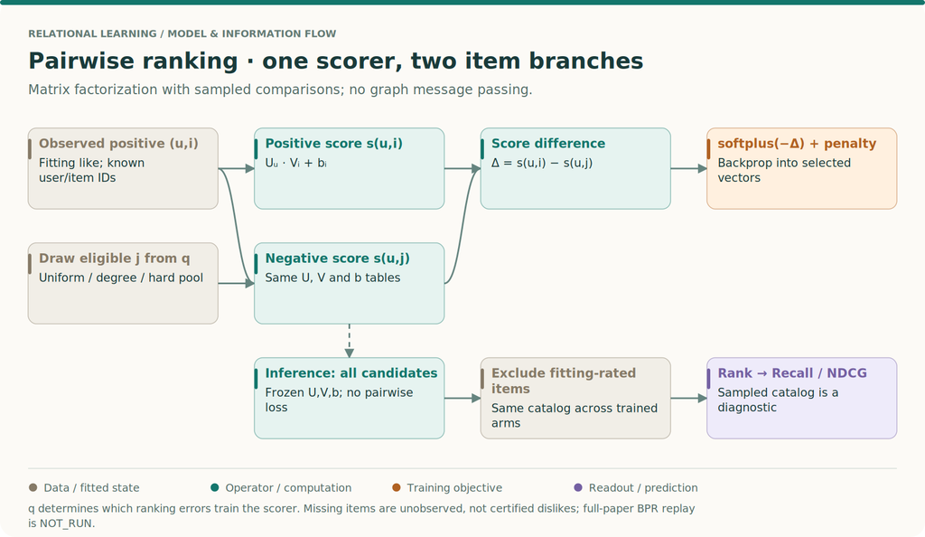

Matrix factorization with sampled comparisons; no graph message passing. q determines which ranking errors train the scorer. Missing items are unobserved, not certified dislikes; full-paper BPR replay is NOT_RUN.

### Follow the shared parameters

There are two score evaluations but one scorer. The user vector appears in both, and the positive and negative items are rows of the same item table. Write the difference as `Δ = U_u · (V_i − V_j) + b_i − b_j`. This makes the comparison explicit: the loss trains a relative ordering for one user. A user-only additive bias would cancel from this difference, which is why it would not help distinguish that user's two items.

The [BPR paper, §4 and §5.1](https://arxiv.org/abs/1205.2618) supplies the pairwise-ranking rationale and matrix-factorization handoff. The course experiment's optimizer, regularizer scaling and candidate policies are documented separately below. “Uses the BPR loss” is a narrower claim than “reproduces LearnBPR.”

### Differentiate one pair before training many

Take a scalar user vector `U=2`, positive item `V_i=1`, negative item `V_j=.5`, and zero biases. Scores are 2 and 1, so Δ=1 and the data loss is `softplus(-1)≈.3133`. The derivative with respect to Δ is approximately −.2689. Therefore the derivatives with respect to U, V_i and V_j are approximately −.1345, −.5379 and +.5379. Gradient descent raises the positive item vector and lowers the negative item vector in this example.

The general user gradient is `-sigmoid(-Δ) × (V_i−V_j)`. Its direction depends on which negative was sampled. Changing q therefore changes more than computational cost: it changes the weighting of update directions. These numbers omit the declared regularizer to isolate the data term, and use one pair rather than a batch mean.

### Make the target expectation explicit

Suppose the eligible candidates are a and b, and their pair losses are .2 and .8. Uniform sampling has expected loss .5. Sampling probabilities `.9,.1` give .26. Neither number is a biased calculation of its own declared expectation. They are different expectations. To estimate the uniform target with the latter sampler, importance weights are `.5/.9` and `.5/.1`; the weighted expectation returns .5, with potentially worse variance.

Coverage matters. If q assigns zero probability to b while the target assigns positive probability, no finite importance weight can recover b's contribution from those samples. A hard-negative selector adds another issue: its distribution changes with the current model. The lab deliberately compares uncorrected policies and labels them as different training objectives.

### Keep the evaluation question fixed

At inference, freeze the scorer and rank every eligible item under the main protocol. Training may have seen only one comparison item at a time, but that does not justify evaluating only one comparison. Conversely, evaluation candidates must not flow backward into the fitting exclusion mask unless the experiment explicitly allows that information. An unobserved item can later become a held-out positive; that uncertainty is part of implicit feedback.

**Predict first: can an item with the smallest score still be a harmful negative?**

Yes. Its true preference is unobserved, so an easy negative can still be a false negative. “Hard” describes the current scorer's difficulty, not the correctness of the assumed comparison. A high score increases the pairwise loss but does not certify a negative label.

**Bridge to L098.** Write three different random variables: the negative item j, the sampled message neighborhood, and the evaluation candidate subset. They affect the objective, encoder computation, and reported metric respectively. Keeping their seeds equal does not make them the same intervention. Reproduce the scalar gradients tomorrow, then explain which table rows receive updates and why the same trained weights can produce different sampled-catalog metrics.

## 2 · Missing means unobserved

Take the relation **user → likes → item**. User 0 has fitting observations for items 0 and 1. Item 2 will appear as a positive in the test file, but the training process does not know that. Items 3 and 4 have no observed interaction for this user.

| Candidate | Information available during fitting | Sampling decision |
| --- | --- | --- |
| user 0 → item 0 | Observed fitting interaction | Exclude |
| user 0 → item 1 | Observed fitting interaction | Exclude |
| user 0 → item 2 | Unobserved during fitting | Eligible; may be a false negative |
| user 0 → item 3 or 4 | Unobserved during fitting | Eligible; truth unknown |
| user 0 → user 4 | Wrong destination type | Reject before sampling |

A negative **training example** is an assumption used by an objective, not a certified dislike. In the lab, ratings ≥4 are positive likes. We exclude **all** fitting-rated items from the negative pool, including lower ratings, to preserve L095's unobserved-item recommendation task. Using observed low ratings as explicit negatives is a different defensible task, but not this experiment.

**Separate three information policies.** Training excludes pairs known from fitting data. An offline static graph benchmark may explicitly authorize a global positive blacklist, including held-out facts; that uses privileged label knowledge and must be stated. Temporal prediction cannot silently use future links to construct today's training pool. Evaluation may use held-out relevance to compute metrics or build a declared candidate set, but those labels must not flow back into fitting. Our `fit(base, strategy, seed)` has no test argument.

Even a global blacklist cannot prove that all remaining pairs are false. Some true links have never been recorded. For an FK relation, schema constraints also matter: corrupting an order's one known buyer describes a mutually exclusive alternative; corrupting a possible future purchase makes a different kind of assumption.

## 3 · Define the candidate universe before the distribution

For each positive `(u, likes, i)`, hold the source and relation fixed and replace the destination. Let `O_u` be items observed in fitting and let `C_u = all_item_IDs − O_u`. Typed IDs are local: user 0 → item 0 is legal if unobserved. It is not a homogeneous self-loop. A sampler must preserve the source, stay in the destination type, and exclude `O_u`.

For a five-item worked example, let fitting item like-degrees be `[3, 1, 0, 8, 1]` and let user 0 have observed items `{0,1}`. Then `C_0 = {2,3,4}`:

- **Uniform:** every candidate gets probability 1/3.
- **Degree-weighted:** use weight `(degree + 1)^0.75`, then renormalize on `C_0`. The weights are `1, 9^0.75, 2^0.75`; probabilities are approximately `.127, .660, .214`. The added one gives zero-degree items nonzero support. This exponent and smoothing are explicit course choices.
- **Hard:** draw four uniform candidates with replacement, score them using the current model, and keep the largest score. This searches for a mistake the model currently finds plausible. It costs extra scoring and can emphasize unknown positives.

**Portable intervention:** calculate the three distributions in the intervention cell below.

**Predict:** raising the degree of item 3 changes the degree sampler but leaves uniform unchanged. Blocking item 3 removes it entirely and renormalizes the others. A high score does not prove an item is a good negative. In a four-draw hard pool, duplicates are allowed; it need not contain four distinct items.

The visible implementation creates a dense `q[user,item]` matrix for clarity. This costs O(number of users × number of items). The full lab is small enough; a production sampler would use sparse exclusion with bounded retries or another exact conditional sampling method. If `C_u` is empty, the implementation raises an explicit error. It never loops forever or silently emits a positive.

```
weights = (degree + 1) ** 0.75       # training like-degrees only
mass = (~blocked) * weights[None, :]
if (mass.sum(axis=1) == 0).any():
    raise ValueError("No valid negative for at least one source")
q = mass / mass.sum(axis=1, keepdims=True)
```

**PyG is an API, not the information policy.** In PyG 2.6.1, passing `num_nodes=(n_users, n_items)` selects a bipartite universe. The library excludes supplied edges; it does not discover your omitted positives. Its global `negative_sampling` does not promise one source-preserving replacement per positive, and requested counts can be approximate. The lab checks its complete tiny-graph complement but implements our conditional sampler explicitly. See the [pinned implementation](https://pytorch-geometric.readthedocs.io/en/2.6.1/_modules/torch_geometric/utils/_negative_sampling.html).

## 4 · Trace the whole computation

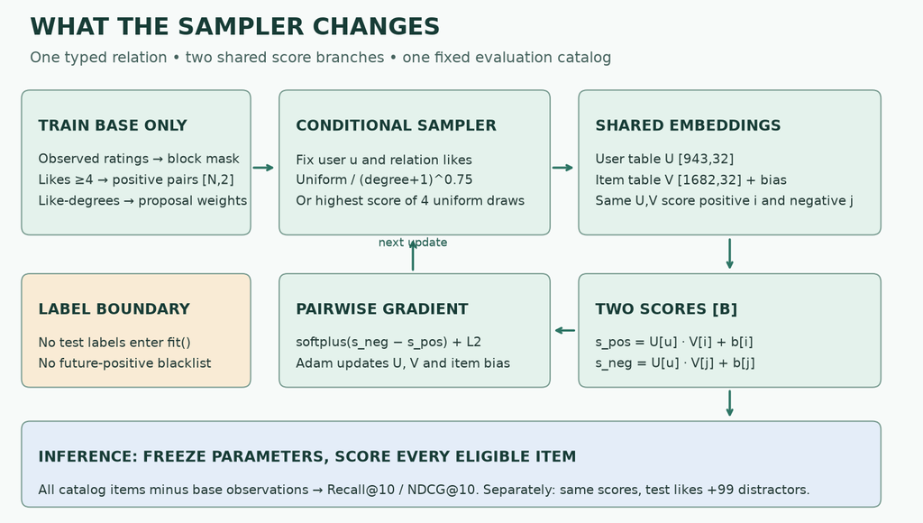

Sampling changes the pairs that produce gradients; evaluation changes the competitors used to measure the frozen scorer.

The scorer deliberately stays simple so the negative distribution is the intervention. Two separate embedding tables hold `U ∈ R^(943×32)` and `V ∈ R^(1682×32)`; items also have scalar biases. For batch size B, user and positive-item lookup tensors have shape `[B,32]`, scores have shape `[B]`, and a hard pool has shape `[B,4]`. Both score branches share the same parameter tables:

`s(u,i) = dot(U[u], V[i]) + b[i]`

This is matrix factorization on a typed relation, not a new heterogeneous GNN. A GNN encoder could supply the embeddings later, but changing the encoder here would obscure the effect of sampling. When transferring this to an R-GCN/HGT model, keep both the forward and reverse target edges out of the held-out message graph.

**Primary reading:** [Rendle et al., BPR, §4.1–4.3 and §5.1](https://arxiv.org/abs/1205.2618). The paper derives a pairwise preference objective and uses a score difference for matrix factorization. Our teaching loss is the negative log-sigmoid of that difference, computed stably:

```
positive_score = (U[u] * V[i]).sum(-1) + b[i]
negative_score = (U[u] * V[j]).sum(-1) + b[j]
loss = torch.nn.functional.softplus(negative_score - positive_score).mean()
```

If both scores are zero, the loss is `log(2) ≈ .6931`. If the positive is 2 and the negative is −1, the loss is `log(1+exp(−3)) ≈ .0486`. The derivative with respect to the positive score is `−sigmoid(s_neg−s_pos)` before batch averaging; the negative-score derivative has the opposite sign. Gradient descent therefore raises the positive relative to the sampled negative. The test checks both the number and the gradient signs.

The trainer adds `.0001 × mean(||U_u||² + ||V_i||² + ||V_j||² + b_i² + b_j²)` and uses Adam at .01 for ten epochs. These optimizer, regularization scaling, dataset, batching and budget choices belong to our experiment. We do not claim to replay the paper's LearnBPR bootstrap-SGD protocol or tables.

## 5 · Changing q changes what gets learned

For a fixed positive `(u,i)`, our expected data loss is:

`L_q(u,i) = Σ[j in C_u] q(j|u) × softplus(s(u,j) − s(u,i))`.

Uniform and degree sampling put different weights on the same possible mistakes. Neither automatically estimates the other's objective. If the desired target distribution is `p`, an importance-weighted term `p(j|u)/q(j|u)` gives an unbiased estimate of that target expectation when `q` covers its support; large ratios can produce high variance. The lab intentionally applies **no** such correction: it measures the effect of changing the training distribution itself.

The hard arm chooses a candidate using **detached current scores**. Gradients pass through the chosen pair's loss, not through the discrete selection. Because this policy depends on the evolving scorer, it is not the fixed `degree` distribution. Its four-candidate scoring budget is larger even though epochs, positive exposures and optimizer updates match.

**Trace one step.** Suppose the positive score is 1 and candidate scores for items `[2,3,4]` are `[.2,1.4,.7]`. Their pairwise losses are approximately `[.371, .913, .554]`. Uniform spreads updates evenly. Degree sampling visits item 3 most often under the worked degrees. A hard draw containing item 3 selects it. If item 3 is actually an undiscovered positive, the strongest gradient can reinforce a wrong assumption.

### How hard is a four-draw pool?

Keep the three fixed candidate scores above: item 2 has .2, item 4 has .7, and item 3 has 1.4. Four independent uniform draws with replacement have **3⁴ = 81 equally likely ordered pools**. Selecting the highest-scoring member gives this distribution:

| Item · score | Pools | Chance |
| --- | --- | --- |
| 2 · score .2 | 1 | 1/81 |
| 4 · score .7 | 15 | 15/81 |
| 3 · score 1.4 | 65 | 65/81 |

The highest-scoring item is absent only if every draw chooses one of the other two: probability `(2/3)⁴ = 16/81`. It therefore wins with probability `1 − 16/81 = 65/81 ≈ .802`. The lowest wins only in the all-item-2 pool. The middle wins in the remaining 15 pools. A four-draw pool is not a guarantee of selecting the hardest eligible item, and it can contain repeated IDs.

**Change the compute budget.** With one draw, each item wins with probability 1/3; with two, the highest wins with probability `1 − (2/3)² = 5/9`. Raising pool size changes the training distribution even with the same scorer, positive examples and epoch count. These probabilities describe a fixed score ordering; they change when training changes that ordering.

**Exercise:** find the expected data loss of the four-draw policy using the three pair losses above. Compare it with the uniform policy; keep the regularizer out of this calculation.

**Weight losses by winning-pool counts**

Pair losses for items 2, 4 and 3 are approximately .3711, .5544 and .9130. The four-draw expectation is (1×.3711 + 15×.5544 + 65×.9130)/81 ≈ .840. The one-draw uniform expectation is approximately .613. This is the intended emphasis on higher-loss comparisons, not proof that those comparisons have correct negative labels.

## 6 · Do not confuse training negatives with evaluation candidates

Freeze a scorer with a relevant item at rank 20 in a catalog of 1,000 candidates. Full-catalog Recall@10 is zero. If you keep the relevant item and only nine distractors, it must be in the top ten: Recall@10 becomes one. No model improvement occurred. With 99 uniformly sampled distractors, its expected number of higher-scoring competitors is `99 × 19/999 ≈ 1.88`; this is an expectation of a count, not an exact expected reciprocal rank.

[Krichene & Rendle, On Sampled Metrics for Item Recommendation](https://www.ijcai.org/proceedings/2021/0651.pdf) establish that sampled metrics need not preserve comparisons between recommenders, even in expectation. Read the introduction and inconsistency discussion after tracing the example. Our lab demonstrates candidate sensitivity on its own protocol; it does not reproduce that paper's experiments or correction estimators.

We evaluate each trained scorer twice:

| Rule | Main measurement | Separate diagnostic |
| --- | --- | --- |
| Candidates | All 1,682 items except fitting-rated items | All test likes plus 99 sampled other eligible items |
| Relevance | Held-out ratings ≥4 | Exactly the same relevance |
| Scores | Frozen learned scores | The same frozen scores |
| Metrics | Macro user Recall@10 and binary NDCG@10 | Same formulas, changed candidate set |
| Randomness | No candidate sampling | Fixed seed per fold/user, shared across arms/seeds |
| Ties | Descending score, then ascending item ID | Same |

For each user, Recall@10 is hits divided by the number of relevant test items. NDCG@10 divides discounted hit gain `Σ hit_r/log2(r+1)` by the ideal gain from `min(10, number_relevant)` hits. Users with no relevant test items are excluded and counted. Unobserved items are treated as nonrelevant for scoring, not established dislikes. Keeping **all** test positives while removing only distractors can only improve or preserve each relevant item's rank here; this diagnostic is deliberately easier.

## 7 · Full declared experiment, not a smoke run

The dataset is the complete [GroupLens MovieLens 100K release](https://files.grouplens.org/datasets/movielens/ml-100k-README.txt): 100,000 ratings, 943 users, 1,682 items, and all five official 80,000/20,000 base/test partitions. The loader verifies the archive SHA-256, recomputes counts, verifies each full partition, and checks that the five test sets partition the release. No row, user, item or split cap is used.

**Protocol:** five folds × seeds `{0,1,2}` × three samplers = **45 complete fits**, each ten epochs over every fitting like. No tuning or early stopping: epoch ten is fixed before results. Positive orders and parameter initializations match across arms for each fold/seed. The degree statistics and exclusion mask use base data only. The test file reaches the evaluator after training; it never changes q, loss or checkpoint selection. These are static offline splits, not a temporal deployment simulation.

**Frozen author measurements; your notebook recomputes all 45 fits.**

| Training sampler | Full Recall@10 | Full NDCG@10 (fold SD) | Sampled NDCG@10 |
| --- | --- | --- | --- |
| uniform | 0.21675 | 0.31339 (0.04043) | 0.73861 |
| degree | 0.18046 | 0.25811 (0.03877) | 0.69444 |
| hard | 0.23742 | 0.34054 (0.03750) | 0.76258 |

Under this fixed budget, hard mining has the highest mean full-catalog NDCG; this includes extra candidate scoring. The sampled evaluation is much easier for every arm. These are course results, not BPR-paper scores.

Read the table in two directions. Compare sampler rows using **full-catalog** metrics to assess this training intervention. Compare full versus sampled columns within the same row to assess candidate sensitivity. Average the three seeds within each fold, then the five fold means; the reported fold SD is descriptive. The folds share data and the seeds are not independent datasets. There is no basis here for a general claim that one sampler wins across recommendation tasks.

**Evidence boundaries:** the roadmap assigns no new model paper to L097. The release reconstruction has an external target. The entire declared training ablation is fresh course evidence. Historical BPR result parity is **NOT_ESTABLISHED**; the BPR paper's experiments are **NOT_RUN**. A full run of this course protocol is not full reproduction of the BPR paper. See the [protocol/deviation ledger](https://avistian.github.io/relational/labs/l097-reproduction.md), [execution evidence](https://avistian.github.io/relational/labs/_experiment_l097_results.json), and [independent result audit](https://avistian.github.io/relational/labs/_audit_l097_results.json).

## 8 · Lab: predict → implement → check → explain

The notebook contains the full loader, sampler, scorer, trainer and evaluator as visible code. It downloads the original archive from GroupLens, verifies it and runs away from this repository. The student implements three load-bearing functions:

1. **`proposal`:** construct and normalize the typed, train-only distribution. CHECK masked support, degree weighting, zero-degree support and the saturated-user error.
2. **`draw_negatives`:** preserve the source while drawing destinations. CHECK the empirical distribution, equal IDs across types, seeded replay and collision exclusion.
3. **`pairwise_loss`:** implement a numerically stable score-difference loss. CHECK the two worked values and both derivative signs.

Then run every declared fold, seed and arm. The notebook saves fresh results and compares deterministic evidence with labeled author references. Its live implementation, not a hidden result loader, drives the experiment. The independent repository auditor recomputes metrics from every saved ranking and independently regenerates training masks and evaluation candidates.

**Intervention:** before running, predict the effect of replacing q by an oracle distribution that excludes the held-out positives. Explain why this might remove false negatives yet invalidate our training-only information policy. Do not quietly make this change and report the result beside the original arms as if protocols were identical.

## 9 · EXIT and spaced retrieval

Submit your three functions, full-run summary, and a written defense answering:

- Why can an unobserved link be both a legal training negative and a later test positive?
- What exactly differs between degree sampling and hard mining? Which has extra compute here?
- Why is a bipartite pair `(0,0)` not necessarily a self-loop?
- Did changing the sampler improve full-catalog ranking, or did changing evaluation candidates inflate the score? Cite actual values separately.
- What can this complete course run reproduce, and which BPR-paper results remain unrun?

Status remains **PENDING_WRITTEN_DEFENSE** until you supply this explanation. Teacher execution is not learner mastery. Tomorrow reconstruct `C_u` and the BPR gradient from memory; in a week redo the rank-20 example without notes. Bring follow-up questions to the agent. L098 will combine typed sampling with heterogeneous mini-batches; keep the negative pool, message-passing neighborhood and evaluation catalog as three separate objects.

## Visible implementation

The full experiment runs your functions. Read the data boundary before the sampler; there is no hidden trainer.

```python
import hashlib

import io

import json

import time

import urllib.request

import zipfile

from pathlib import Path

import numpy as np

import torch

import torch.nn.functional as F

ARCHIVE_URL = 'https://files.grouplens.org/datasets/movielens/ml-100k.zip'

ARCHIVE_SHA256 = '50d2a982c66986937beb9ffb3aa76efe955bf3d5c6b761f4e3a7cd717c6a3229'

CONFIG = {'folds': [1,2,3,4,5], 'seeds': [0,1,2], 'arms': ['uniform','degree','hard'],
          'epochs': 10, 'dimension': 32, 'batch_size': 2048, 'lr': .01,
          'l2': .0001, 'hard_pool': 4, 'sampled_distractors': 99, 'k': 10}
```

### PROVIDED · load_release

Fetch original bytes, then audit every row of all five official partitions.

```python
def load_release(path):
    """Fetch original bytes, then audit every row of all five official partitions."""
    path=Path(path);path.parent.mkdir(parents=True,exist_ok=True)
    if not path.exists():
        tmp=path.with_suffix('.partial');urllib.request.urlretrieve(ARCHIVE_URL,tmp)
        if hashlib.sha256(tmp.read_bytes()).hexdigest()!=ARCHIVE_SHA256:
            tmp.unlink();raise ValueError('Downloaded archive hash mismatch')
        tmp.replace(path)
    if hashlib.sha256(path.read_bytes()).hexdigest()!=ARCHIVE_SHA256:raise ValueError('Archive hash mismatch')
    arrays={};hashes={}
    with zipfile.ZipFile(path) as z:
        for name in ['u.data']+[f'u{f}.{part}' for f in range(1,6) for part in ['base','test']]:
            raw=z.read('ml-100k/'+name);hashes[name]=hashlib.sha256(raw).hexdigest()
            a=np.loadtxt(io.BytesIO(raw),dtype=np.int64);a[:,:2]-=1;arrays[name]=a
    full=arrays['u.data'];truth=set(map(tuple,full));seen=set()
    assert len(full)==len(truth)==len(set(map(tuple,full[:,:2])))==100000
    assert set(full[:,0])==set(range(943)) and set(full[:,1])==set(range(1682))
    assert np.bincount(full[:,0]).min()==20
    for fold in range(1,6):
        a,b=arrays[f'u{fold}.base'],arrays[f'u{fold}.test'];sa,sb=set(map(tuple,a)),set(map(tuple,b))
        assert len(a)==len(sa)==80000 and len(b)==len(sb)==20000
        assert not sa&sb and sa|sb==truth and not seen&sb;seen|=sb
    assert seen==truth
    return arrays,hashes
```

### PROVIDED · training_inputs

Only base rows enter masks, degrees and positives. Ratings >=4 are likes.

```python
def training_inputs(base,n_users=943,n_items=1682):
    """Only base rows enter masks, degrees and positives. Ratings >=4 are likes."""
    blocked=np.zeros((n_users,n_items),dtype=bool);blocked[base[:,0],base[:,1]]=True
    positive=base[base[:,2]>=4,:2].copy()
    degree=np.bincount(positive[:,1],minlength=n_items)
    return positive,blocked,degree
```

### TODO · proposal

TODO: return normalized q(item|user) over unobserved typed destinations.

uniform uses unit weights; degree uses (like_degree+1)^0.75. Empty rows fail. This dense pedagogical implementation costs O(users*items), not production scale.

```python
def proposal(blocked,degree,strategy):
    """TODO: return normalized q(item|user) over unobserved typed destinations.

    uniform uses unit weights; degree uses (like_degree+1)^0.75. Empty rows fail.
    This dense pedagogical implementation costs O(users*items), not production scale.
    """
    blocked=np.asarray(blocked);degree=np.asarray(degree,dtype=float)
    if blocked.ndim!=2 or blocked.dtype!=bool or degree.shape!=(blocked.shape[1],):raise ValueError('Invalid typed shapes')
    if not np.isfinite(degree).all() or (degree<0).any():raise ValueError('Invalid degrees')
    if strategy=='uniform':weights=np.ones(len(degree))
    elif strategy=='degree':weights=(degree+1)**.75
    else:raise ValueError('Unknown proposal')
    mass=(~blocked)*weights[None,:];totals=mass.sum(1,keepdims=True)
    if (totals==0).any():raise ValueError('No valid negative for at least one source')
    return mass/totals
```

### CHECK · proposal

```python
blocked=np.array([[True,True,False,False,False]])
degree=np.array([3,1,0,8,1])
q=proposal(blocked,degree,'uniform')
assert np.allclose(q,[[0,0,1/3,1/3,1/3]])
qd=proposal(blocked,degree,'degree')
assert qd[0,3]>qd[0,4]>qd[0,2]>0
try: proposal(np.ones((1,3),bool),np.ones(3),'uniform')
except ValueError: pass
else: raise AssertionError('Empty pool must fail')
print('PASS: support, weights, zero-degree support, saturation')
```

```
PASS: support, weights, zero-degree support, saturation
```

### TODO · draw_negatives

TODO: one independent replacement draw per source, preserving user identity.

Group inverse-CDF queries by user. Equal user/item indices are valid typed pairs. Duplicates across draws are allowed; positive collisions have probability zero.

```python
def draw_negatives(users,q,rng):
    """TODO: one independent replacement draw per source, preserving user identity.

    Group inverse-CDF queries by user. Equal user/item indices are valid typed pairs.
    Duplicates across draws are allowed; positive collisions have probability zero.
    """
    users=np.asarray(users,dtype=np.int64)
    if users.ndim!=1 or ((users<0)|(users>=len(q))).any():raise ValueError('Invalid source IDs')
    out=np.empty(len(users),dtype=np.int64);uniforms=rng.random(len(users))
    for u in np.unique(users):
        locations=np.flatnonzero(users==u);cdf=np.cumsum(q[u]);cdf[-1]=1.
        out[locations]=np.searchsorted(cdf,uniforms[locations],side='right')
    return out
```

### CHECK · draw_negatives

```python
users=np.zeros(30000,dtype=int)
j=draw_negatives(users,q,np.random.default_rng(97))
assert not blocked[users,j].any()
assert max(abs(np.bincount(j,minlength=5)[2:]/30000-1/3))<.02
assert draw_negatives(np.array([0]),np.array([[1.,0.]]),np.random.default_rng(0)).item()==0
assert np.array_equal(draw_negatives(users[:100],q,np.random.default_rng(7)),draw_negatives(users[:100],q,np.random.default_rng(7)))
print('PASS: conditional draws, typed identity, frequencies, seed replay')
```

```
PASS: conditional draws, typed identity, frequencies, seed replay
```

### TODO · pairwise_loss

TODO: mean negative log sigmoid(score_positive - score_negative), stably.

```python
def pairwise_loss(positive_score,negative_score):
    """TODO: mean negative log sigmoid(score_positive - score_negative), stably."""
    return F.softplus(negative_score-positive_score).mean()
```

### CHECK · pairwise_loss

```python
sp=torch.tensor([0.,2.],requires_grad=True);sn=torch.tensor([0.,-1.],requires_grad=True)
loss=pairwise_loss(sp,sn)
assert abs(loss.item()-(np.log(2)+np.log1p(np.exp(-3)))/2)<1e-7
loss.backward();assert (sp.grad<0).all() and (sn.grad>0).all()
print('PASS: stable objective and gradient signs')
```

```
PASS: stable objective and gradient signs
```

### PROVIDED · fit

Visible fixed-budget MF trainer. Heldout data are not an argument.

Shared initial weights and positive orders across arms; fresh negatives each epoch. Hard arm chooses the largest detached score from four uniform candidate draws.

```python
def fit(base,strategy,seed,config=CONFIG):
    """Visible fixed-budget MF trainer. Heldout data are not an argument.

    Shared initial weights and positive orders across arms; fresh negatives each epoch.
    Hard arm chooses the largest detached score from four uniform candidate draws.
    """
    torch.set_num_threads(1);torch.use_deterministic_algorithms(True);torch.manual_seed(seed)
    positive,blocked,degree=training_inputs(base)
    q=proposal(blocked,degree,'degree' if strategy=='degree' else 'uniform')
    user=torch.nn.Parameter(torch.randn(943,config['dimension'])*.1)
    item=torch.nn.Parameter(torch.randn(1682,config['dimension'])*.1)
    bias=torch.nn.Parameter(torch.zeros(1682))
    initial=hashlib.sha256(user.detach().numpy().tobytes()+item.detach().numpy().tobytes()).hexdigest()
    opt=torch.optim.Adam([user,item,bias],lr=config['lr'])
    order_rng=np.random.default_rng(9700+seed);negative_rng=np.random.default_rng(19700+seed)
    trace=[];negative_hash=hashlib.sha256();collisions=0;draws=0
    for epoch in range(config['epochs']):
        order=order_rng.permutation(len(positive));loss_sum=0.
        # Draw one (or four hard-pool) candidates per positive before batching.
        width=config['hard_pool'] if strategy=='hard' else 1
        repeated=np.repeat(positive[:,0],width)
        candidates=draw_negatives(repeated,q,negative_rng).reshape(-1,width)
        assert not blocked[repeated,candidates.ravel()].any()
        for start in range(0,len(order),config['batch_size']):
            ids=order[start:start+config['batch_size']];u,i=positive[ids].T
            cand=torch.from_numpy(candidates[ids]);ut=torch.from_numpy(u);it=torch.from_numpy(i)
            if strategy=='hard':
                with torch.no_grad():
                    scores=(user[ut,None,:]*item[cand]).sum(-1)+bias[cand]
                    j=cand[torch.arange(len(ids)),scores.argmax(1)]
            else:j=cand[:,0]
            negative_hash.update(j.numpy().tobytes());draws+=len(ids)
            collisions+=int(blocked[u,j.numpy()].sum())
            sp=(user[ut]*item[it]).sum(1)+bias[it]
            sn=(user[ut]*item[j]).sum(1)+bias[j]
            reg=(user[ut].square().sum(1)+item[it].square().sum(1)+item[j].square().sum(1)+bias[it].square()+bias[j].square()).mean()
            loss=pairwise_loss(sp,sn)+config['l2']*reg
            opt.zero_grad();loss.backward();opt.step();loss_sum+=loss.item()*len(ids)
        trace.append(loss_sum/len(positive))
    with torch.no_grad():scores=(user@item.T+bias).numpy()
    assert np.isfinite(scores).all() and collisions==0
    return scores,blocked,{'loss_by_epoch':trace,'positive_rows':len(positive),'negative_draws':draws,'known_positive_collisions':collisions,'initial_sha256':initial,'negatives_sha256':negative_hash.hexdigest()}
```

### PROVIDED · evaluate

Same full-catalog rule for every arm; separate fixed sampled-candidate diagnostic.

Binary relevant = test rating >=4. Exclude base-rated items. Macro over users with >=1 relevant item. Ties use ascending item ID. Full and sampled share scores.

```python
def evaluate(scores,blocked,test,seed,k=10,distractors=99):
    """Same full-catalog rule for every arm; separate fixed sampled-candidate diagnostic.

    Binary relevant = test rating >=4. Exclude base-rated items. Macro over users
    with >=1 relevant item. Ties use ascending item ID. Full and sampled share scores.
    """
    truth={}
    for u,i,rating,_ in test:
        if rating>=4:truth.setdefault(int(u),set()).add(int(i))
    records=[];totals=[]
    for u,relevant in sorted(truth.items()):
        candidates=np.flatnonzero(~blocked[u]);rel=sorted(relevant)
        assert set(rel)<=set(candidates),'Heldout/base overlap'
        negatives=np.array([i for i in candidates if i not in relevant],dtype=np.int64)
        rng=np.random.default_rng(seed*10000+u)
        sampled=np.sort(np.concatenate([np.array(rel),rng.choice(negatives,min(distractors,len(negatives)),replace=False)]))
        row={'user':u,'relevant':rel,'full_candidates':len(candidates),'sampled_candidates':len(sampled)};values=[]
        for label,pool in [('full',candidates),('sampled',sampled)]:
            top=pool[np.lexsort((pool,-scores[u,pool]))[:k]]
            hit=np.isin(top,rel);recall=float(hit.sum()/len(rel))
            ndcg=float(np.sum(hit/np.log2(np.arange(len(top))+2))/np.sum(1/np.log2(np.arange(min(k,len(rel)))+2)))
            row[label+'_top']=top.tolist();row[label+'_recall']=recall;row[label+'_ndcg']=ndcg
            values.extend([recall,ndcg])
        records.append(row);totals.append(values)
    if not records:raise ValueError('No evaluable users')
    keys=['full_recall','full_ndcg','sampled_recall','sampled_ndcg']
    result=dict(zip(keys,map(float,np.mean(totals,axis=0))))
    result.update({'evaluated_users':len(records),'excluded_users':len(scores)-len(records)})
    return result,records
```

### PROVIDED · run_suite

All five official folds x three seeds x three samplers, no subsampling/resume.

```python
def run_suite(archive,output_dir):
    """All five official folds x three seeds x three samplers, no subsampling/resume."""
    start=time.monotonic();arrays,hashes=load_release(archive);out=Path(output_dir);out.mkdir(parents=True,exist_ok=True)
    rows=[]
    for fold in CONFIG['folds']:
        base,test=arrays[f'u{fold}.base'],arrays[f'u{fold}.test']
        for seed in CONFIG['seeds']:
            for arm in CONFIG['arms']:
                scores,blocked,training=fit(base,arm,seed)
                metrics,records=evaluate(scores,blocked,test,970+fold,k=CONFIG['k'],distractors=CONFIG['sampled_distractors'])
                name=f'fold{fold}-seed{seed}-{arm}.json';payload=json.dumps(records,separators=(',',':'))+'\n'
                (out/name).write_text(payload)
                row={'fold':fold,'seed':seed,'arm':arm,**metrics,**training,'records_file':name,'records_sha256':hashlib.sha256(payload.encode()).hexdigest()};rows.append(row)
                print(f"fold={fold} seed={seed} arm={arm}: full NDCG={metrics['full_ndcg']:.5f}, sampled={metrics['sampled_ndcg']:.5f}",flush=True)
    summary={}
    for arm in CONFIG['arms']:
        summary[arm]={}
        for metric in ['full_recall','full_ndcg','sampled_recall','sampled_ndcg']:
            folds=[float(np.mean([r[metric] for r in rows if r['arm']==arm and r['fold']==f])) for f in CONFIG['folds']]
            summary[arm][metric]={'mean':float(np.mean(folds)),'fold_means':folds,'fold_sd':float(np.std(folds,ddof=1))}
    return {'status':'MEASURED','scope':'complete course experiment; not historical BPR reproduction','config':CONFIG,'archive_sha256':ARCHIVE_SHA256,'member_sha256':hashes,'runs':rows,'summary':summary,'seconds':time.monotonic()-start,'paper_parity':'NOT_ESTABLISHED','learner':'PENDING_WRITTEN_DEFENSE'}
```

## Predict → intervene → explain

Before execution, predict which probabilities move when item 3 becomes observed. Explain why item 2 may remain a legal negative even if it is positive in heldout data.

```python
blocked=np.array([[True,True,False,False,False]])
degree=np.array([3,1,0,8,1])
print('uniform',proposal(blocked,degree,'uniform'))
print('degree',proposal(blocked,degree,'degree'))
blocked[0,3]=True
print('new observation',proposal(blocked,degree,'degree'))
assert proposal(blocked,degree,'degree')[0,3]==0
```

```
uniform [[0.         0.         0.33333333 0.33333333 0.33333333]]
degree [[0.         0.         0.12693665 0.6595822  0.21348115]]
new observation [[0.         0.         0.37288488 0.         0.62711512]]
```

## Full reproduction of the declared course experiment

Every fit starts fresh. Data remain complete, including all five official partitions. This is not a reproduction of the historical BPR experiment. Author execution was approximately 50 CPU seconds; other devices/environments can differ.

```python
fresh=run_suite('l097-data/ml-100k.zip','l097-results')
Path('l097-fresh.json').write_text(json.dumps(fresh,indent=2)+'\n')
assert len(fresh['runs'])==45
assert all(r['known_positive_collisions']==0 for r in fresh['runs'])
AUTHOR_SUMMARY={'uniform': {'full_recall': {'mean': 0.21674636070051806, 'fold_means': [0.19493759514017436, 0.20725813009071517, 0.22073841614023315, 0.2291931807154596, 0.2316044814160079], 'fold_sd': 0.015469909192404867}, 'full_ndcg': {'mean': 0.3133897741879652, 'fold_means': [0.3778703359648237, 0.3288993953318399, 0.2852917312772491, 0.2889845650560456, 0.28590284330986765], 'fold_sd': 0.04043184639726549}, 'sampled_recall': {'mean': 0.5649513946341979, 'fold_means': [0.4690338368903196, 0.5428675913963925, 0.5982331633090218, 0.6051455594510339, 0.6094768221242218], 'fold_sd': 0.05998673385343875}, 'sampled_ndcg': {'mean': 0.7386120399136937, 'fold_means': [0.7906980002312617, 0.7590408990954703, 0.7198064978286288, 0.7164959366796285, 0.7070188657334788], 'fold_sd': 0.03525331416982841}}, 'degree': {'full_recall': {'mean': 0.18045926698025144, 'fold_means': [0.16507719183845104, 0.178833955050841, 0.17989860644758793, 0.18160005211919314, 0.19688652944518417], 'fold_sd': 0.011299563681773095}, 'full_ndcg': {'mean': 0.25810612728910304, 'fold_means': [0.3189079917973678, 0.2740374185471029, 0.23700613899587278, 0.22438663682600815, 0.2361924502791635], 'fold_sd': 0.03877207613731099}, 'sampled_recall': {'mean': 0.5365878941962947, 'fold_means': [0.45202590189088837, 0.514149391749446, 0.5636202318950936, 0.5774797351299185, 0.5756642103161274], 'fold_sd': 0.05381464798876004}, 'sampled_ndcg': {'mean': 0.6944396746520474, 'fold_means': [0.7541816602813971, 0.7170677725107931, 0.674645757525188, 0.6673630355070269, 0.6589401474358317], 'fold_sd': 0.04020664010717592}}, 'hard': {'full_recall': {'mean': 0.23741864377065927, 'fold_means': [0.20508103998957147, 0.23233766413778156, 0.24440754192639738, 0.24956075499040167, 0.25570621780914427], 'fold_sd': 0.020014044436653017}, 'full_ndcg': {'mean': 0.3405350640450058, 'fold_means': [0.3994090839431183, 0.35669109599099186, 0.3149993197506096, 0.31261158392407623, 0.31896423661623297], 'fold_sd': 0.03749754379255295}, 'sampled_recall': {'mean': 0.5857865368602753, 'fold_means': [0.48438997444786214, 0.5627842249000531, 0.6175181885572144, 0.6306138114756237, 0.6336264849206238], 'fold_sd': 0.06347324657649539}, 'sampled_ndcg': {'mean': 0.7625772818814275, 'fold_means': [0.807847156492666, 0.7831843089897168, 0.7455480327115289, 0.7442843555310587, 0.7320225556821667], 'fold_sd': 0.03174991688343977}}}
gaps={a:abs(fresh['summary'][a]['full_ndcg']['mean']-AUTHOR_SUMMARY[a]['full_ndcg']['mean']) for a in CONFIG['arms']}
print('Absolute full-NDCG differences from frozen author references:',gaps)
print(json.dumps(fresh['summary'],indent=2))
# A different package/device can change optimization. Investigate differences; never relabel them as paper parity.
```

```
fold=1 seed=0 arm=uniform: full NDCG=0.37022, sampled=0.79331
```

```
fold=1 seed=0 arm=degree: full NDCG=0.31167, sampled=0.75179
```

```
fold=1 seed=0 arm=hard: full NDCG=0.39445, sampled=0.80723
```

```
fold=1 seed=1 arm=uniform: full NDCG=0.38219, sampled=0.79147
```

```
fold=1 seed=1 arm=degree: full NDCG=0.31932, sampled=0.74988
```

```
fold=1 seed=1 arm=hard: full NDCG=0.40391, sampled=0.80847
```

```
fold=1 seed=2 arm=uniform: full NDCG=0.38120, sampled=0.78731
```

```
fold=1 seed=2 arm=degree: full NDCG=0.32573, sampled=0.76088
```

```
fold=1 seed=2 arm=hard: full NDCG=0.39987, sampled=0.80784
```

```
fold=2 seed=0 arm=uniform: full NDCG=0.34152, sampled=0.76131
```

```
fold=2 seed=0 arm=degree: full NDCG=0.27450, sampled=0.71159
```

```
fold=2 seed=0 arm=hard: full NDCG=0.36022, sampled=0.78668
```

```
fold=2 seed=1 arm=uniform: full NDCG=0.32319, sampled=0.75683
```

```
fold=2 seed=1 arm=degree: full NDCG=0.27975, sampled=0.71882
```

```
fold=2 seed=1 arm=hard: full NDCG=0.34984, sampled=0.78073
```

```
fold=2 seed=2 arm=uniform: full NDCG=0.32199, sampled=0.75898
```

```
fold=2 seed=2 arm=degree: full NDCG=0.26787, sampled=0.72079
```

```
fold=2 seed=2 arm=hard: full NDCG=0.36002, sampled=0.78214
```

```
fold=3 seed=0 arm=uniform: full NDCG=0.29509, sampled=0.72908
```

```
fold=3 seed=0 arm=degree: full NDCG=0.24599, sampled=0.68141
```

```
fold=3 seed=0 arm=hard: full NDCG=0.31817, sampled=0.74697
```

```
fold=3 seed=1 arm=uniform: full NDCG=0.27735, sampled=0.71314
```

```
fold=3 seed=1 arm=degree: full NDCG=0.23341, sampled=0.67114
```

```
fold=3 seed=1 arm=hard: full NDCG=0.31380, sampled=0.74253
```

```
fold=3 seed=2 arm=uniform: full NDCG=0.28343, sampled=0.71720
```

```
fold=3 seed=2 arm=degree: full NDCG=0.23162, sampled=0.67139
```

```
fold=3 seed=2 arm=hard: full NDCG=0.31303, sampled=0.74714
```

```
fold=4 seed=0 arm=uniform: full NDCG=0.29404, sampled=0.72587
```

```
fold=4 seed=0 arm=degree: full NDCG=0.23241, sampled=0.67233
```

```
fold=4 seed=0 arm=hard: full NDCG=0.32033, sampled=0.75009
```

```
fold=4 seed=1 arm=uniform: full NDCG=0.28531, sampled=0.71150
```

```
fold=4 seed=1 arm=degree: full NDCG=0.22045, sampled=0.66861
```

```
fold=4 seed=1 arm=hard: full NDCG=0.31250, sampled=0.74258
```

```
fold=4 seed=2 arm=uniform: full NDCG=0.28760, sampled=0.71211
```

```
fold=4 seed=2 arm=degree: full NDCG=0.22029, sampled=0.66115
```

```
fold=4 seed=2 arm=hard: full NDCG=0.30500, sampled=0.74018
```

```
fold=5 seed=0 arm=uniform: full NDCG=0.29286, sampled=0.71482
```

```
fold=5 seed=0 arm=degree: full NDCG=0.23930, sampled=0.66370
```

```
fold=5 seed=0 arm=hard: full NDCG=0.32067, sampled=0.73327
```

```
fold=5 seed=1 arm=uniform: full NDCG=0.28342, sampled=0.70084
```

```
fold=5 seed=1 arm=degree: full NDCG=0.23348, sampled=0.65398
```

```
fold=5 seed=1 arm=hard: full NDCG=0.32137, sampled=0.73248
```

```
fold=5 seed=2 arm=uniform: full NDCG=0.28144, sampled=0.70540
```

```
fold=5 seed=2 arm=degree: full NDCG=0.23580, sampled=0.65914
```

```
fold=5 seed=2 arm=hard: full NDCG=0.31485, sampled=0.73032
```

```
Absolute full-NDCG differences from frozen author references: {'uniform': 0.0, 'degree': 0.0, 'hard': 0.0}
{
  "uniform": {
    "full_recall": {
      "mean": 0.21674636070051806,
      "fold_means": [
        0.19493759514017436,
        0.20725813009071517,
        0.22073841614023315,
        0.2291931807154596,
        0.2316044814160079
      ],
      "fold_sd": 0.015469909192404867
    },
    "full_ndcg": {
      "mean": 0.3133897741879652,
      "fold_means": [
        0.3778703359648237,
        0.3288993953318399,
        0.2852917312772491,
        0.2889845650560456,
        0.28590284330986765
      ],
      "fold_sd": 0.04043184639726549
    },
    "sampled_recall": {
      "mean": 0.5649513946341979,
      "fold_means": [
        0.4690338368903196,
        0.5428675913963925,
        0.5982331633090218,
        0.6051455594510339,
        0.6094768221242218
      ],
      "fold_sd": 0.05998673385343875
    },
    "sampled_ndcg": {
      "mean": 0.7386120399136937,
      "fold_means": [
        0.7906980002312617,
```

[output cut: 86 more lines]

```
      "fold_sd": 0.06347324657649539
    },
    "sampled_ndcg": {
      "mean": 0.7625772818814275,
      "fold_means": [
        0.807847156492666,
        0.7831843089897168,
        0.7455480327115289,
        0.7442843555310587,
        0.7320225556821667
      ],
      "fold_sd": 0.03174991688343977
    }
  }
}
```

## EXIT · PENDING_WRITTEN_DEFENSE

Submit your functions, l097-fresh.json, and the five section 9 answers. Defend the candidate universe and training information boundary before comparing metrics. Ask the agent for feedback; execution alone is not mastery.